# Risk Factor Analysis

## Outcome Variable

**Outcome Variable:** ever_swasted

## Predictor Variables

**Intervention Variable:** fhtcm

**Adjustment Set:**

unadjusted

## Stratifying Variables

The analysis was stratified on these variable(s):

- agecat
- studyid
- country

## Data Summary

| agecat | studyid | country | fhtcm | ever_swasted | n_cell | n |
| --- | --- | --- | --- | --- | --- | --- |
| 0-24 months | ki1000304b-SAS-CompFeed | INDIA | >=167 cm | 0 | 96 | 243 |
| 0-24 months | ki1000304b-SAS-CompFeed | INDIA | >=167 cm | 1 | 14 | 243 |
| 0-24 months | ki1000304b-SAS-CompFeed | INDIA | <162 cm | 0 | 51 | 243 |
| 0-24 months | ki1000304b-SAS-CompFeed | INDIA | <162 cm | 1 | 9 | 243 |
| 0-24 months | ki1000304b-SAS-CompFeed | INDIA | [162-167) cm | 0 | 61 | 243 |
| 0-24 months | ki1000304b-SAS-CompFeed | INDIA | [162-167) cm | 1 | 12 | 243 |
| 0-24 months | ki1000304b-SAS-FoodSuppl | INDIA | >=167 cm | 0 | 17 | 101 |
| 0-24 months | ki1000304b-SAS-FoodSuppl | INDIA | >=167 cm | 1 | 4 | 101 |
| 0-24 months | ki1000304b-SAS-FoodSuppl | INDIA | <162 cm | 0 | 31 | 101 |
| 0-24 months | ki1000304b-SAS-FoodSuppl | INDIA | <162 cm | 1 | 7 | 101 |
| 0-24 months | ki1000304b-SAS-FoodSuppl | INDIA | [162-167) cm | 0 | 34 | 101 |
| 0-24 months | ki1000304b-SAS-FoodSuppl | INDIA | [162-167) cm | 1 | 8 | 101 |
| 0-24 months | ki1101329-Keneba | GAMBIA | >=167 cm | 0 | 1054 | 1933 |
| 0-24 months | ki1101329-Keneba | GAMBIA | >=167 cm | 1 | 194 | 1933 |
| 0-24 months | ki1101329-Keneba | GAMBIA | <162 cm | 0 | 106 | 1933 |
| 0-24 months | ki1101329-Keneba | GAMBIA | <162 cm | 1 | 26 | 1933 |
| 0-24 months | ki1101329-Keneba | GAMBIA | [162-167) cm | 0 | 471 | 1933 |
| 0-24 months | ki1101329-Keneba | GAMBIA | [162-167) cm | 1 | 82 | 1933 |
| 0-24 months | ki1119695-PROBIT | BELARUS | >=167 cm | 0 | 5284 | 6249 |
| 0-24 months | ki1119695-PROBIT | BELARUS | >=167 cm | 1 | 552 | 6249 |
| 0-24 months | ki1119695-PROBIT | BELARUS | <162 cm | 0 | 77 | 6249 |
| 0-24 months | ki1119695-PROBIT | BELARUS | <162 cm | 1 | 6 | 6249 |
| 0-24 months | ki1119695-PROBIT | BELARUS | [162-167) cm | 0 | 312 | 6249 |
| 0-24 months | ki1119695-PROBIT | BELARUS | [162-167) cm | 1 | 18 | 6249 |
| 0-24 months | ki1135781-COHORTS | GUATEMALA | >=167 cm | 0 | 26 | 227 |
| 0-24 months | ki1135781-COHORTS | GUATEMALA | >=167 cm | 1 | 2 | 227 |
| 0-24 months | ki1135781-COHORTS | GUATEMALA | <162 cm | 0 | 111 | 227 |
| 0-24 months | ki1135781-COHORTS | GUATEMALA | <162 cm | 1 | 11 | 227 |
| 0-24 months | ki1135781-COHORTS | GUATEMALA | [162-167) cm | 0 | 72 | 227 |
| 0-24 months | ki1135781-COHORTS | GUATEMALA | [162-167) cm | 1 | 5 | 227 |

[output cut: 60 more lines]

The following strata were considered:

- agecat: 0-24 months, studyid: ki1000304b-SAS-CompFeed, country: INDIA
- agecat: 0-24 months, studyid: ki1000304b-SAS-FoodSuppl, country: INDIA
- agecat: 0-24 months, studyid: ki1101329-Keneba, country: GAMBIA
- agecat: 0-24 months, studyid: ki1119695-PROBIT, country: BELARUS
- agecat: 0-24 months, studyid: ki1135781-COHORTS, country: GUATEMALA
- agecat: 0-6 months, studyid: ki1000304b-SAS-CompFeed, country: INDIA
- agecat: 0-6 months, studyid: ki1000304b-SAS-FoodSuppl, country: INDIA
- agecat: 0-6 months, studyid: ki1101329-Keneba, country: GAMBIA
- agecat: 0-6 months, studyid: ki1119695-PROBIT, country: BELARUS
- agecat: 0-6 months, studyid: ki1135781-COHORTS, country: GUATEMALA
- agecat: 6-24 months, studyid: ki1000304b-SAS-CompFeed, country: INDIA
- agecat: 6-24 months, studyid: ki1000304b-SAS-FoodSuppl, country: INDIA
- agecat: 6-24 months, studyid: ki1101329-Keneba, country: GAMBIA
- agecat: 6-24 months, studyid: ki1119695-PROBIT, country: BELARUS
- agecat: 6-24 months, studyid: ki1135781-COHORTS, country: GUATEMALA

### Dropped Strata

Some strata were dropped due to rare outcomes:

- agecat: 0-24 months, studyid: ki1000304b-SAS-FoodSuppl, country: INDIA
- agecat: 0-24 months, studyid: ki1135781-COHORTS, country: GUATEMALA
- agecat: 0-6 months, studyid: ki1000304b-SAS-CompFeed, country: INDIA
- agecat: 0-6 months, studyid: ki1000304b-SAS-FoodSuppl, country: INDIA
- agecat: 0-6 months, studyid: ki1135781-COHORTS, country: GUATEMALA
- agecat: 6-24 months, studyid: ki1000304b-SAS-FoodSuppl, country: INDIA
- agecat: 6-24 months, studyid: ki1119695-PROBIT, country: BELARUS
- agecat: 6-24 months, studyid: ki1135781-COHORTS, country: GUATEMALA

## Methods Detail

We’re interested in the causal parameters $E[Y_a]$ for all values of $a \in \mathcal{A}$. These parameters represent the mean outcome if, possibly contrary to fact, we intervened to set all units to have $A=a$. Under the randomization and positivity assumptions, these are identified by the statistical parameters $\psi_a=E_W[E_{Y|A,W}(Y|A=a,W)]$. In addition, we’re interested in the mean of $Y$, $E[Y]$ under no intervention (the observed mean). We will estimate these parameters by using SuperLearner to fit the relevant likelihood factors – $E_{Y|A,W}(Y|A=a,W)$ and $p(A=a|W)$, and then updating our likelihood fit using a joint TMLE.

For unadjusted analyses ($W=\{\}$), initial likelihoods were estimated using Lrnr_glm to estimate the simple $E(Y|A)$ and Lrnr_mean to estimate $p(A)$. For adjusted analyses, a small library containing Lrnr_glmnet, Lrnr_xgboost, and Lrnr_mean was used.

Having estimated these parameters, we will then use the delta method to estimate relative risks and attributable risks relative to a prespecified baseline level of $A$.

# Results Detail

## Results Plots

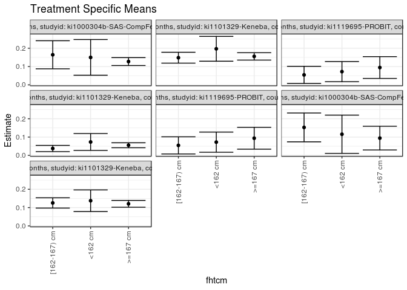

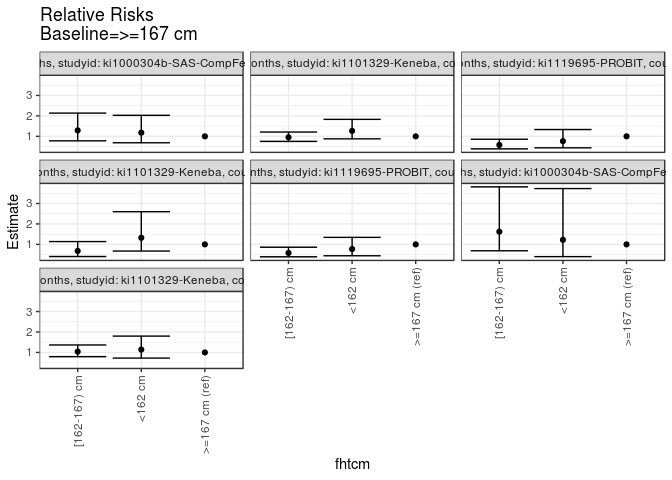

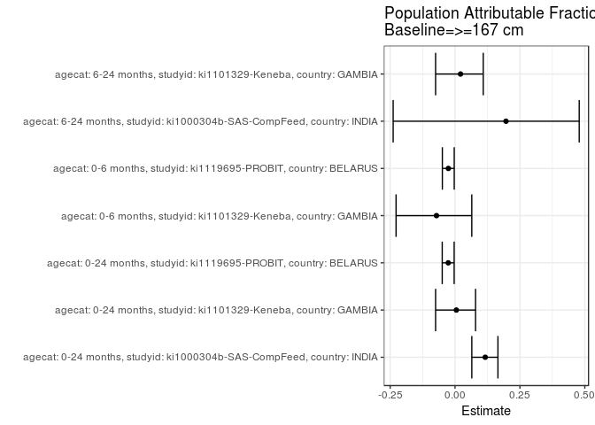

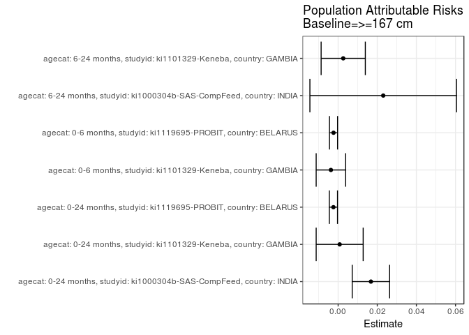

## Results Table

### Parameter: TSM

| agecat | studyid | country | intervention_level | baseline_level | estimate | ci_lower | ci_upper |
| --- | --- | --- | --- | --- | --- | --- | --- |
| 0-24 months | ki1000304b-SAS-CompFeed | INDIA | >=167 cm | NA | 0.1272727 | 0.1056167 | 0.1489288 |
| 0-24 months | ki1000304b-SAS-CompFeed | INDIA | <162 cm | NA | 0.1500000 | 0.0525090 | 0.2474910 |
| 0-24 months | ki1000304b-SAS-CompFeed | INDIA | [162-167) cm | NA | 0.1643836 | 0.0876774 | 0.2410897 |
| 0-24 months | ki1101329-Keneba | GAMBIA | >=167 cm | NA | 0.1554487 | 0.1353411 | 0.1755563 |
| 0-24 months | ki1101329-Keneba | GAMBIA | <162 cm | NA | 0.1969697 | 0.1291057 | 0.2648337 |
| 0-24 months | ki1101329-Keneba | GAMBIA | [162-167) cm | NA | 0.1482821 | 0.1186549 | 0.1779093 |
| 0-24 months | ki1119695-PROBIT | BELARUS | >=167 cm | NA | 0.0945853 | 0.0350531 | 0.1541176 |
| 0-24 months | ki1119695-PROBIT | BELARUS | <162 cm | NA | 0.0722892 | 0.0172644 | 0.1273139 |
| 0-24 months | ki1119695-PROBIT | BELARUS | [162-167) cm | NA | 0.0545455 | 0.0076808 | 0.1014102 |
| 0-6 months | ki1101329-Keneba | GAMBIA | >=167 cm | NA | 0.0553037 | 0.0418106 | 0.0687968 |
| 0-6 months | ki1101329-Keneba | GAMBIA | <162 cm | NA | 0.0731707 | 0.0271354 | 0.1192061 |
| 0-6 months | ki1101329-Keneba | GAMBIA | [162-167) cm | NA | 0.0375783 | 0.0205426 | 0.0546139 |
| 0-6 months | ki1119695-PROBIT | BELARUS | >=167 cm | NA | 0.0937286 | 0.0340397 | 0.1534174 |
| 0-6 months | ki1119695-PROBIT | BELARUS | <162 cm | NA | 0.0722892 | 0.0172644 | 0.1273139 |
| 0-6 months | ki1119695-PROBIT | BELARUS | [162-167) cm | NA | 0.0545455 | 0.0076808 | 0.1014102 |
| 6-24 months | ki1000304b-SAS-CompFeed | INDIA | >=167 cm | NA | 0.0943396 | 0.0295417 | 0.1591376 |
| 6-24 months | ki1000304b-SAS-CompFeed | INDIA | <162 cm | NA | 0.1153846 | 0.0108270 | 0.2199422 |
| 6-24 months | ki1000304b-SAS-CompFeed | INDIA | [162-167) cm | NA | 0.1527778 | 0.0740552 | 0.2315004 |
| 6-24 months | ki1101329-Keneba | GAMBIA | >=167 cm | NA | 0.1205734 | 0.1020360 | 0.1391107 |
| 6-24 months | ki1101329-Keneba | GAMBIA | <162 cm | NA | 0.1374046 | 0.0784342 | 0.1963750 |
| 6-24 months | ki1101329-Keneba | GAMBIA | [162-167) cm | NA | 0.1254682 | 0.0973654 | 0.1535710 |

### Parameter: E(Y)

| agecat | studyid | country | intervention_level | baseline_level | estimate | ci_lower | ci_upper |
| --- | --- | --- | --- | --- | --- | --- | --- |
| 0-24 months | ki1000304b-SAS-CompFeed | INDIA | NA | NA | 0.1440329 | 0.1156404 | 0.1724254 |
| 0-24 months | ki1101329-Keneba | GAMBIA | NA | NA | 0.1562338 | 0.1400440 | 0.1724237 |
| 0-24 months | ki1119695-PROBIT | BELARUS | NA | NA | 0.0921747 | 0.0334053 | 0.1509442 |
| 0-6 months | ki1101329-Keneba | GAMBIA | NA | NA | 0.0516129 | 0.0411082 | 0.0621176 |
| 0-6 months | ki1119695-PROBIT | BELARUS | NA | NA | 0.0913746 | 0.0324470 | 0.1503022 |
| 6-24 months | ki1000304b-SAS-CompFeed | INDIA | NA | NA | 0.1173913 | 0.0746040 | 0.1601786 |
| 6-24 months | ki1101329-Keneba | GAMBIA | NA | NA | 0.1231767 | 0.1082011 | 0.1381522 |

### Parameter: RR

| agecat | studyid | country | intervention_level | baseline_level | estimate | ci_lower | ci_upper |
| --- | --- | --- | --- | --- | --- | --- | --- |
| 0-24 months | ki1000304b-SAS-CompFeed | INDIA | >=167 cm | >=167 cm | 1.0000000 | 1.0000000 | 1.0000000 |
| 0-24 months | ki1000304b-SAS-CompFeed | INDIA | <162 cm | >=167 cm | 1.1785714 | 0.6854236 | 2.0265287 |
| 0-24 months | ki1000304b-SAS-CompFeed | INDIA | [162-167) cm | >=167 cm | 1.2915851 | 0.7805786 | 2.1371225 |
| 0-24 months | ki1101329-Keneba | GAMBIA | >=167 cm | >=167 cm | 1.0000000 | 1.0000000 | 1.0000000 |
| 0-24 months | ki1101329-Keneba | GAMBIA | <162 cm | >=167 cm | 1.2671040 | 0.8769657 | 1.8308044 |
| 0-24 months | ki1101329-Keneba | GAMBIA | [162-167) cm | >=167 cm | 0.9538972 | 0.7518501 | 1.2102411 |
| 0-24 months | ki1119695-PROBIT | BELARUS | >=167 cm | >=167 cm | 1.0000000 | 1.0000000 | 1.0000000 |
| 0-24 months | ki1119695-PROBIT | BELARUS | <162 cm | >=167 cm | 0.7642745 | 0.4384627 | 1.3321898 |
| 0-24 months | ki1119695-PROBIT | BELARUS | [162-167) cm | >=167 cm | 0.5766798 | 0.3873135 | 0.8586317 |
| 0-6 months | ki1101329-Keneba | GAMBIA | >=167 cm | >=167 cm | 1.0000000 | 1.0000000 | 1.0000000 |
| 0-6 months | ki1101329-Keneba | GAMBIA | <162 cm | >=167 cm | 1.3230708 | 0.6737840 | 2.5980377 |
| 0-6 months | ki1101329-Keneba | GAMBIA | [162-167) cm | >=167 cm | 0.6794894 | 0.4060674 | 1.1370176 |
| 0-6 months | ki1119695-PROBIT | BELARUS | >=167 cm | >=167 cm | 1.0000000 | 1.0000000 | 1.0000000 |
| 0-6 months | ki1119695-PROBIT | BELARUS | <162 cm | >=167 cm | 0.7712605 | 0.4430895 | 1.3424892 |
| 0-6 months | ki1119695-PROBIT | BELARUS | [162-167) cm | >=167 cm | 0.5819511 | 0.3928385 | 0.8621027 |
| 6-24 months | ki1000304b-SAS-CompFeed | INDIA | >=167 cm | >=167 cm | 1.0000000 | 1.0000000 | 1.0000000 |
| 6-24 months | ki1000304b-SAS-CompFeed | INDIA | <162 cm | >=167 cm | 1.2230769 | 0.4011631 | 3.7289501 |
| 6-24 months | ki1000304b-SAS-CompFeed | INDIA | [162-167) cm | >=167 cm | 1.6194444 | 0.6877707 | 3.8131897 |
| 6-24 months | ki1101329-Keneba | GAMBIA | >=167 cm | >=167 cm | 1.0000000 | 1.0000000 | 1.0000000 |
| 6-24 months | ki1101329-Keneba | GAMBIA | <162 cm | >=167 cm | 1.1395932 | 0.7223764 | 1.7977785 |
| 6-24 months | ki1101329-Keneba | GAMBIA | [162-167) cm | >=167 cm | 1.0405961 | 0.7930426 | 1.3654250 |

### Parameter: PAR

| agecat | studyid | country | intervention_level | baseline_level | estimate | ci_lower | ci_upper |
| --- | --- | --- | --- | --- | --- | --- | --- |
| 0-24 months | ki1000304b-SAS-CompFeed | INDIA | >=167 cm | NA | 0.0167602 | 0.0071970 | 0.0263234 |
| 0-24 months | ki1101329-Keneba | GAMBIA | >=167 cm | NA | 0.0007851 | -0.0112295 | 0.0127998 |
| 0-24 months | ki1119695-PROBIT | BELARUS | >=167 cm | NA | -0.0024106 | -0.0045027 | -0.0003185 |
| 0-6 months | ki1101329-Keneba | GAMBIA | >=167 cm | NA | -0.0036908 | -0.0112308 | 0.0038492 |
| 0-6 months | ki1119695-PROBIT | BELARUS | >=167 cm | NA | -0.0023540 | -0.0044234 | -0.0002845 |
| 6-24 months | ki1000304b-SAS-CompFeed | INDIA | >=167 cm | NA | 0.0230517 | -0.0144309 | 0.0605342 |
| 6-24 months | ki1101329-Keneba | GAMBIA | >=167 cm | NA | 0.0026033 | -0.0086902 | 0.0138968 |

### Parameter: PAF

| agecat | studyid | country | intervention_level | baseline_level | estimate | ci_lower | ci_upper |
| --- | --- | --- | --- | --- | --- | --- | --- |
| 0-24 months | ki1000304b-SAS-CompFeed | INDIA | >=167 cm | NA | 0.1163636 | 0.0646005 | 0.1652623 |
| 0-24 months | ki1101329-Keneba | GAMBIA | >=167 cm | NA | 0.0050253 | -0.0749253 | 0.0790292 |
| 0-24 months | ki1119695-PROBIT | BELARUS | >=167 cm | NA | -0.0261523 | -0.0494103 | -0.0034099 |
| 0-6 months | ki1101329-Keneba | GAMBIA | >=167 cm | NA | -0.0715095 | -0.2272890 | 0.0644969 |
| 0-6 months | ki1119695-PROBIT | BELARUS | >=167 cm | NA | -0.0257617 | -0.0488997 | -0.0031341 |
| 6-24 months | ki1000304b-SAS-CompFeed | INDIA | >=167 cm | NA | 0.1963662 | -0.2384614 | 0.4785244 |
| 6-24 months | ki1101329-Keneba | GAMBIA | >=167 cm | NA | 0.0211347 | -0.0749535 | 0.1086338 |